# EDA 與建模報告：breast_cancer_diagnosis.csv

任務：分類（二元分類）｜目標：`diagnosis`｜產生：2026-10-16 19:38｜遺失值：無｜最佳模型：Gradient Boosting

**569**列數

**30**特徵數（數值 30 / 類別 0）

**無**遺失值

**Gradient Boosting**最佳模型（依 CV）

**0.998**最佳模型測試 AUC

## 1. 資料與變數介紹

- **分析目的（要預測什麼）**：預測 `diagnosis`，共 2 類：benign（357 筆）、malignant（212 筆）。這是一個分類問題（判斷依據見第 2 節）。
- **用了哪些變數**：30 個特徵（數值 30、類別 0）——`mean_radius`；`mean_texture`；`mean_perimeter`；`mean_area`；`mean_smoothness`；`mean_compactness`；`mean_concavity`；`mean_concave_points`；`mean_symmetry`；`mean_fractal_dimension`；`radius_error`；`texture_error`；`perimeter_error`；`area_error`；`smoothness_error`；`compactness_error`；`concavity_error`；`concave_points_error`；`symmetry_error`；`fractal_dimension_error`；`worst_radius`；`worst_texture`；`worst_perimeter`；`worst_area`；`worst_smoothness`；`worst_compactness`；`worst_concavity`；`worst_concave_points`；`worst_symmetry`；`worst_fractal_dimension`。
- 資料共 **569 筆、31 個欄位**：目標 1 個（`diagnosis`）、特徵 30 個（數值 30、類別 0）、ID／排除 0 個。
- 沒有 ID 類欄位，所有非目標欄位都當作特徵。
- 完全重複的列 0 筆；常數欄位 無。（未提供欄位說明檔，可用 --dict 指定，讓下表帶出中文說明與單位。）

### 變數與欄位介紹

| 欄位 | 說明 | 單位 | 角色 | 變數型態 | dtype | 遺失數 |
| --- | --- | --- | --- | --- | --- | --- |
| mean_radius | — | — | 特徵 | 數值 | float64 | 0 |
| mean_texture | — | — | 特徵 | 數值 | float64 | 0 |
| mean_perimeter | — | — | 特徵 | 數值 | float64 | 0 |
| mean_area | — | — | 特徵 | 數值 | float64 | 0 |
| mean_smoothness | — | — | 特徵 | 數值 | float64 | 0 |
| mean_compactness | — | — | 特徵 | 數值 | float64 | 0 |
| mean_concavity | — | — | 特徵 | 數值 | float64 | 0 |
| mean_concave_points | — | — | 特徵 | 數值 | float64 | 0 |
| mean_symmetry | — | — | 特徵 | 數值 | float64 | 0 |
| mean_fractal_dimension | — | — | 特徵 | 數值 | float64 | 0 |
| radius_error | — | — | 特徵 | 數值 | float64 | 0 |
| texture_error | — | — | 特徵 | 數值 | float64 | 0 |
| perimeter_error | — | — | 特徵 | 數值 | float64 | 0 |
| area_error | — | — | 特徵 | 數值 | float64 | 0 |
| smoothness_error | — | — | 特徵 | 數值 | float64 | 0 |
| compactness_error | — | — | 特徵 | 數值 | float64 | 0 |
| concavity_error | — | — | 特徵 | 數值 | float64 | 0 |
| concave_points_error | — | — | 特徵 | 數值 | float64 | 0 |
| symmetry_error | — | — | 特徵 | 數值 | float64 | 0 |
| fractal_dimension_error | — | — | 特徵 | 數值 | float64 | 0 |
| worst_radius | — | — | 特徵 | 數值 | float64 | 0 |
| worst_texture | — | — | 特徵 | 數值 | float64 | 0 |
| worst_perimeter | — | — | 特徵 | 數值 | float64 | 0 |
| worst_area | — | — | 特徵 | 數值 | float64 | 0 |
| worst_smoothness | — | — | 特徵 | 數值 | float64 | 0 |
| worst_compactness | — | — | 特徵 | 數值 | float64 | 0 |
| worst_concavity | — | — | 特徵 | 數值 | float64 | 0 |
| worst_concave_points | — | — | 特徵 | 數值 | float64 | 0 |
| worst_symmetry | — | — | 特徵 | 數值 | float64 | 0 |
| worst_fractal_dimension | — | — | 特徵 | 數值 | float64 | 0 |
| diagnosis | — | — | 目標 | 類別（標籤） | str | 0 |

## 2. 判斷任務類型（分類 or 迴歸）

- **判斷結果：分類（二元分類）**。理由：目標是文字／布林值，代表「類別」而非數量。
- 分類 = 預測「屬於哪一類」，輸出類別或機率；評估用 AUC、PR-AUC、F1、混淆矩陣；切分要 stratify 保持類別比例。
- 判斷規則：文字／布林 → 分類；只有 2 種值 → 二元分類；整數且 ≤10 種值 → 多類別分類（需確認是否為計數/評分）；其餘數值 → 迴歸。任務類型決定了之後的模型（Classifier vs Regressor）、評估指標與切分方式，所以是第一步。

### 任務類型判斷

| 檢查項目 | 結果 |
| --- | --- |
| 目標欄位 | diagnosis |
| dtype | str |
| 是否為數值 | 否 |
| 是否全為整數 | 否 |
| 不同值個數 | 2 |
| 不同值佔比 | 0.35% |
| 範例值 | malignant, benign |
| 判斷 | 分類：二元分類 |

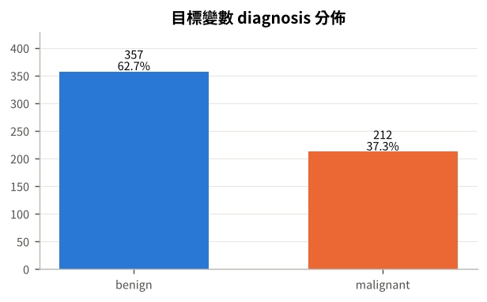

目標變數分佈：分類看各類別比例（是否不平衡）；迴歸看分佈形狀與偏態。

## 3. 敘述性統計

- 目標類別分佈：0=357（62.7%）, 1=212（37.3%）。類別不平衡，評估請看 AUC / PR-AUC / F1，不要只看 accuracy；切分要 stratify。
- 偏態 |skew|>1 的欄位：mean_area（1.64）、mean_compactness（1.19）、mean_concavity（1.40）、mean_concave_points（1.17）、mean_fractal_dimension（1.30）、radius_error（3.08）、texture_error（1.64）、perimeter_error（3.44）、area_error（5.43）、smoothness_error（2.31）、compactness_error（1.90）、concavity_error（5.10）、concave_points_error（1.44）、symmetry_error（2.19）、fractal_dimension_error（3.91）、worst_radius（1.10）、worst_perimeter（1.12）、worst_area（1.85）、worst_compactness（1.47）、worst_concavity（1.15）、worst_symmetry（1.43）、worst_fractal_dimension（1.66）。樹模型不受單調轉換影響，不必為了模型做 log；但線性模型或距離型插補（KNN）會受影響。
- 單變量與目標關係最強的特徵：worst_concave_points（SMD=2.60）、worst_perimeter（SMD=2.37）、mean_concave_points（SMD=2.33）、worst_radius（SMD=2.32）。這只是單變量篩選，交互作用與非線性要靠後面的模型。
- 高度相關（|ρ|>0.8）的特徵對共 40 對，最高的 8 對：mean_radius–mean_area（1.00）、worst_radius–worst_area（1.00）、mean_radius–mean_perimeter（1.00）、mean_perimeter–mean_area（1.00）、worst_radius–worst_perimeter（0.99）、worst_perimeter–worst_area（0.99）、mean_perimeter–worst_radius（0.98）、mean_perimeter–worst_area（0.98）。樹模型預測不受影響，但重要度會被兩者瓜分，解讀時要合併看；它們也是 MICE/KNN 插補的好幫手。

### 數值敘述統計

| 欄位 | 個數 | 遺失% | 平均數 | 標準差 | 最小值 | Q1 | 中位數 | Q3 | 最大值 | IQR | 變異係數CV | 偏態 | 峰態(超額) | 離群值數(1.5IQR) |
| --- | --- | --- | --- | --- | --- | --- | --- | --- | --- | --- | --- | --- | --- | --- |
| mean_radius | 569 | 0 | 14.13 | 3.524 | 6.981 | 11.7 | 13.37 | 15.78 | 28.11 | 4.08 | 0.249 | 0.94 | 0.828 | 14 |
| mean_texture | 569 | 0 | 19.29 | 4.301 | 9.71 | 16.17 | 18.84 | 21.8 | 39.28 | 5.63 | 0.223 | 0.649 | 0.741 | 7 |
| mean_perimeter | 569 | 0 | 91.97 | 24.3 | 43.79 | 75.17 | 86.24 | 104.1 | 188.5 | 28.93 | 0.264 | 0.988 | 0.953 | 13 |
| mean_area | 569 | 0 | 654.9 | 351.9 | 143.5 | 420.3 | 551.1 | 782.7 | 2,501 | 362.4 | 0.537 | 1.641 | 3.61 | 25 |
| mean_smoothness | 569 | 0 | 0.096 | 0.014 | 0.053 | 0.086 | 0.096 | 0.105 | 0.163 | 0.019 | 0.146 | 0.455 | 0.838 | 6 |
| mean_compactness | 569 | 0 | 0.104 | 0.053 | 0.019 | 0.065 | 0.093 | 0.13 | 0.345 | 0.065 | 0.506 | 1.187 | 1.625 | 16 |
| mean_concavity | 569 | 0 | 0.089 | 0.08 | 0 | 0.03 | 0.062 | 0.131 | 0.427 | 0.101 | 0.898 | 1.397 | 1.971 | 18 |
| mean_concave_points | 569 | 0 | 0.049 | 0.039 | 0 | 0.02 | 0.034 | 0.074 | 0.201 | 0.054 | 0.793 | 1.168 | 1.047 | 10 |
| mean_symmetry | 569 | 0 | 0.181 | 0.027 | 0.106 | 0.162 | 0.179 | 0.196 | 0.304 | 0.034 | 0.151 | 0.724 | 1.266 | 15 |
| mean_fractal_dimension | 569 | 0 | 0.063 | 0.007 | 0.05 | 0.058 | 0.062 | 0.066 | 0.097 | 0.008 | 0.112 | 1.301 | 2.969 | 15 |
| radius_error | 569 | 0 | 0.405 | 0.277 | 0.112 | 0.232 | 0.324 | 0.479 | 2.873 | 0.246 | 0.684 | 3.08 | 17.52 | 38 |
| texture_error | 569 | 0 | 1.217 | 0.552 | 0.36 | 0.834 | 1.108 | 1.474 | 4.885 | 0.64 | 0.453 | 1.642 | 5.292 | 20 |
| perimeter_error | 569 | 0 | 2.866 | 2.022 | 0.757 | 1.606 | 2.287 | 3.357 | 21.98 | 1.751 | 0.705 | 3.435 | 21.2 | 38 |
| area_error | 569 | 0 | 40.34 | 45.49 | 6.802 | 17.85 | 24.53 | 45.19 | 542.2 | 27.34 | 1.128 | 5.433 | 48.77 | 65 |
| smoothness_error | 569 | 0 | 0.007 | 0.003 | 0.002 | 0.005 | 0.006 | 0.008 | 0.031 | 0.003 | 0.426 | 2.308 | 10.37 | 30 |
| compactness_error | 569 | 0 | 0.025 | 0.018 | 0.002 | 0.013 | 0.02 | 0.032 | 0.135 | 0.019 | 0.703 | 1.897 | 5.051 | 28 |
| concavity_error | 569 | 0 | 0.032 | 0.03 | 0 | 0.015 | 0.026 | 0.042 | 0.396 | 0.027 | 0.946 | 5.097 | 48.42 | 22 |
| concave_points_error | 569 | 0 | 0.012 | 0.006 | 0 | 0.008 | 0.011 | 0.015 | 0.053 | 0.007 | 0.523 | 1.441 | 5.071 | 19 |
| symmetry_error | 569 | 0 | 0.021 | 0.008 | 0.008 | 0.015 | 0.019 | 0.023 | 0.079 | 0.008 | 0.402 | 2.189 | 7.816 | 27 |
| fractal_dimension_error | 569 | 0 | 0.004 | 0.003 | 0.001 | 0.002 | 0.003 | 0.005 | 0.03 | 0.002 | 0.697 | 3.914 | 26.04 | 28 |
| worst_radius | 569 | 0 | 16.27 | 4.833 | 7.93 | 13.01 | 14.97 | 18.79 | 36.04 | 5.78 | 0.297 | 1.1 | 0.925 | 17 |
| worst_texture | 569 | 0 | 25.68 | 6.146 | 12.02 | 21.08 | 25.41 | 29.72 | 49.54 | 8.64 | 0.239 | 0.497 | 0.212 | 5 |
| worst_perimeter | 569 | 0 | 107.3 | 33.6 | 50.41 | 84.11 | 97.66 | 125.4 | 251.2 | 41.29 | 0.313 | 1.125 | 1.05 | 15 |
| worst_area | 569 | 0 | 880.6 | 569.4 | 185.2 | 515.3 | 686.5 | 1,084 | 4,254 | 568.7 | 0.647 | 1.854 | 4.347 | 35 |
| worst_smoothness | 569 | 0 | 0.132 | 0.023 | 0.071 | 0.117 | 0.131 | 0.146 | 0.223 | 0.029 | 0.172 | 0.414 | 0.503 | 7 |
| worst_compactness | 569 | 0 | 0.254 | 0.157 | 0.027 | 0.147 | 0.212 | 0.339 | 1.058 | 0.192 | 0.619 | 1.47 | 3.002 | 16 |
| worst_concavity | 569 | 0 | 0.272 | 0.209 | 0 | 0.114 | 0.227 | 0.383 | 1.252 | 0.268 | 0.766 | 1.147 | 1.591 | 12 |
| worst_concave_points | 569 | 0 | 0.115 | 0.066 | 0 | 0.065 | 0.1 | 0.161 | 0.291 | 0.096 | 0.574 | 0.491 | -0.541 | 0 |
| worst_symmetry | 569 | 0 | 0.29 | 0.062 | 0.156 | 0.25 | 0.282 | 0.318 | 0.664 | 0.068 | 0.213 | 1.43 | 4.395 | 23 |
| worst_fractal_dimension | 569 | 0 | 0.084 | 0.018 | 0.055 | 0.071 | 0.08 | 0.092 | 0.208 | 0.021 | 0.215 | 1.658 | 5.188 | 24 |

### 類別敘述統計

| 欄位 | 個數 | 遺失% | 類別數 | 眾數 | 眾數佔比% | 最少類別 | 最少類別佔比% | 各類別次數 |
| --- | --- | --- | --- | --- | --- | --- | --- | --- |
| diagnosis | 569 | 0 | 2 | benign | 62.74 | malignant | 37.26 | benign=357; malignant=212 |

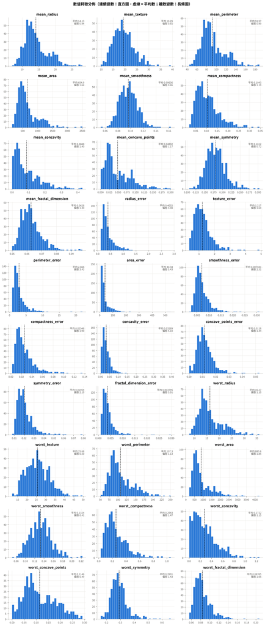

連續變數用直方圖（虛線為平均數），取值少的離散變數（如房間數、車位數）用長條圖；右上角為平均數與偏態。

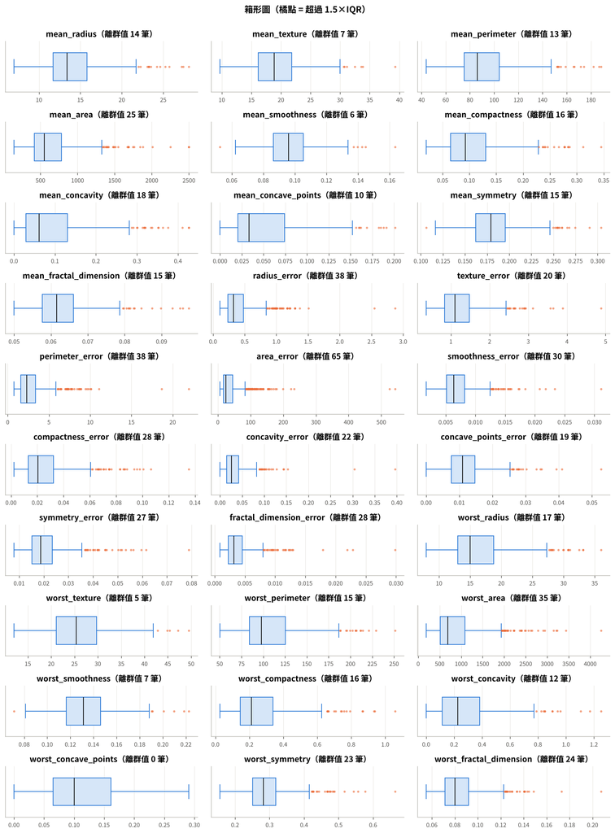

箱形圖：橘點為 1.5×IQR 外的離群值；樹模型對離群值穩健，但明顯的輸入錯誤仍應修正。

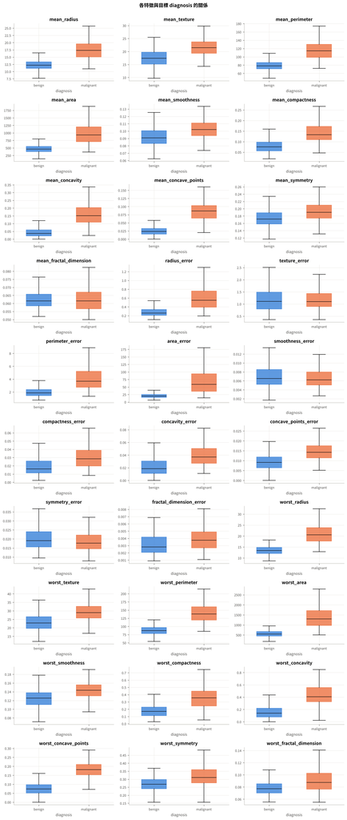

雙變量分析：分類看各類別的分佈差異或各水準的目標比率；迴歸看趨勢與非線性。

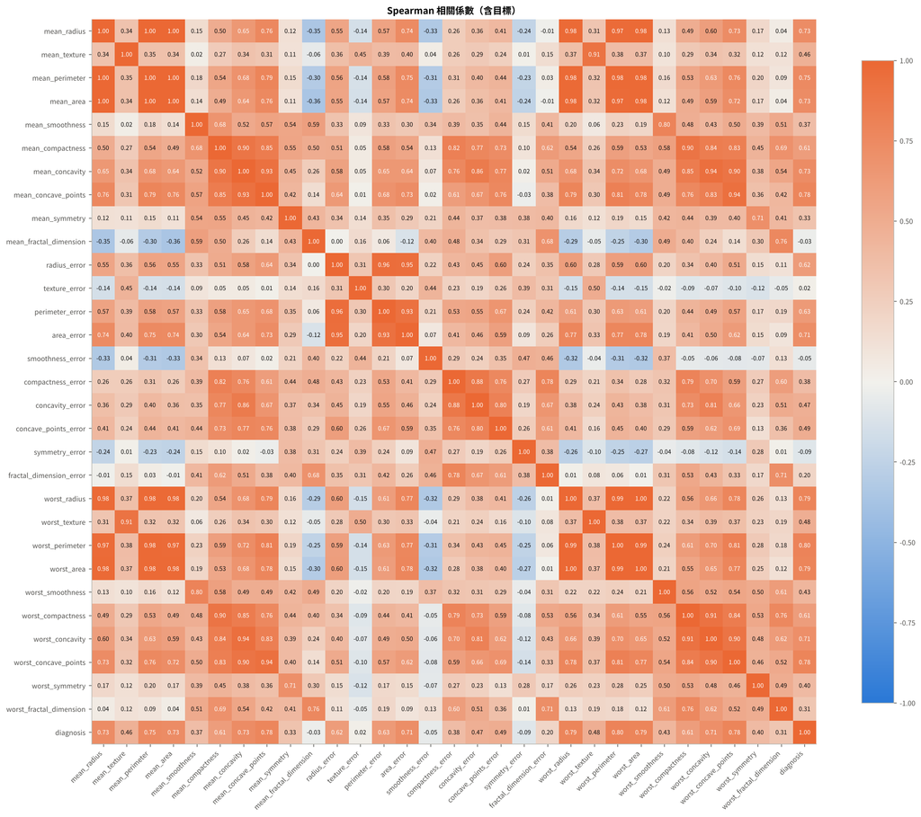

Spearman 相關（對偏態與單調非線性較穩健）：找共線性與和目標相關的特徵。

## 4. 遺失值檢查

- **沒有遺失值**：30 個特徵 × 569 筆資料都完整，**不需要做遺失值診斷與插補**，直接進入資料切分與建模。（遺失值的檢查仍必做——上線資料可能出現遺失，屆時再依本 skill 的遺失值流程處理。）

### 遺失值檢查

| 項目 | 結果 |
| --- | --- |
| 特徵欄位數 | 30 |
| 資料筆數 | 569 |
| 總格數 | 17,070 |
| 遺失格數 | 0（0.00%） |
| 有遺失的欄位數 | 0 |
| 完整列比例 | 100.0% |
| 判斷 | 無遺失 → 跳過遺失值診斷與處理 |

## 5. 資料切分

- **為什麼要切分**：模型在「看過的資料」上的分數一定偏樂觀（尤其是會記住資料的深樹）。必須留一份完全沒碰過的資料，才能估計上線後的真實表現。
- **本次做法**：先切出 25% 測試集（143 筆，鎖起來直到最後），剩下 426 筆訓練集再做 5 折交叉驗證（StratifiedKFold）：每次用 4 折訓練、1 折驗證，輪流 5 次取平均。模型用 CV 分數挑選，測試集只在最後報告一次。
- **分類要 stratify**：讓每份資料的類別比例都和全體相同，否則少數類別可能在某一份裡特別少，分數忽高忽低。
- 切分後各類別筆數（訓練 / 測試）：benign 267 / 90、malignant 159 / 53；合計 426 / 143。各類別在訓練、測試中的比例都和全體一致（stratify 的效果）。
- **避免洩漏**：插補、編碼、特徵選擇都放進 Pipeline，在每一折只用該折的訓練資料 fit；**不要**在切分前對全部資料算平均數補值或標準化。
- **其他切分情境**：有時間順序 → TimeSeriesSplit（只能用過去預測未來）；同一客戶/病人有多筆 → GroupKFold（同一群不能同時出現在訓練與驗證）；Boosting 的 early stopping → 再從訓練集切出一小份驗證集；資料很少 → 用重複 CV（RepeatedKFold）讓估計更穩。

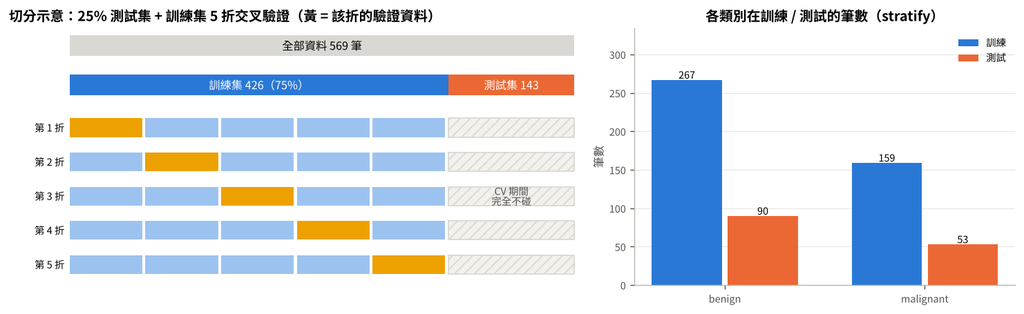

左：切分流程——測試集先鎖起來，訓練集內輪流用其中 1 折當驗證；右：檢查切分後目標分佈是否一致。

### 資料切分（各類別筆數）

| 類別 | 全部筆數 | 訓練筆數 | 測試筆數 | 訓練佔該類% | 測試佔該類% | 訓練集內佔比% | 測試集內佔比% |
| --- | --- | --- | --- | --- | --- | --- | --- |
| benign | 357 | 267 | 90 | 74.8 | 25.2 | 62.7 | 62.9 |
| malignant | 212 | 159 | 53 | 75 | 25 | 37.3 | 37.1 |
| 合計 | 569 | 426 | 143 | 74.9 | 25.1 | 100 | 100 |

### 交叉驗證各折

| 折 | 訓練筆數 | 驗證筆數 | 驗證折 benign 筆數 | 驗證折 malignant 筆數 |
| --- | --- | --- | --- | --- |
| 1 | 340 | 86 | 54 | 32 |
| 2 | 341 | 85 | 54 | 31 |
| 3 | 341 | 85 | 53 | 32 |
| 4 | 341 | 85 | 53 | 32 |
| 5 | 341 | 85 | 53 | 32 |

## 6. 模型訓練與比較（分類）

- 比較三個樹模型：**Decision Tree**（單棵樹，可解釋）、**Random Forest**（多棵深樹平均，降方差）、**Gradient Boosting**（多棵淺樹接力修正殘差，降偏差）。三者使用相同的前處理 Pipeline 與相同的 CV 折，比較才公平。
- **調參方式**：每個樹模型都用 **GridSearchCV** 在訓練集上做 5 折交叉驗證，窮舉「模型參數與調參」表中的參數組合，選 CV AUC 最好的一組，再用整個訓練集重新訓練；最後只在測試集評估一次。註：調參後的 CV 分數因為是「挑過的最佳值」而略偏樂觀，所以最終以測試集確認。
- ⚠ 最佳參數落在搜尋範圍的邊界：Decision Tree 的 min_samples_leaf=20、Gradient Boosting 的 max_depth=4。代表更好的值可能在範圍外，實務上應擴大該參數的搜尋範圍再跑一次。
- 指標：AUC（排序能力，0.5=亂猜、1=完美）、PR-AUC 與 F1（以 **malignant** 為正類計算；隨機猜時 PR-AUC 等於正類比例 37.3%）、Accuracy（閾值 0.5 下的整體正確率；類別不平衡時會誤導）。文字標籤依字母排序編碼：benign = 0、malignant = 1。
- 依 CV 選出最佳模型 **Gradient Boosting**：CV AUC 0.992±0.004，測試集 AUC 0.998、PR-AUC 0.996、F1 0.951。
- 訓練/測試 AUC 差距 0.002：過擬合可接受。
- 測試集 143 筆，AUC 標準誤約 ±0.02；模型之間 <0.01 的差距不應過度解讀。
- 置換重要度（測試集）前五名：area_error（0.0067）、worst_texture（0.0055）、worst_area（0.0053）、mean_concave_points（0.0052）、worst_concave_points（0.0050）。數值 = 打亂該欄後 AUC 變差多少；接近 0 或為負的欄位對模型幾乎沒貢獻。重要度不是因果。

### 模型參數與調參

| 模型 | 調參方式 | 搜尋範圍 | 最佳參數 | 固定參數 | 前處理 |
| --- | --- | --- | --- | --- | --- |
| Decision Tree | GridSearchCV（5 折 CV，24 組 × 5 折 = 120 次訓練） | max_depth ∈ [2, 3, 4, 5, 6, 8]；min_samples_leaf ∈ [1, 5, 10, 20] | max_depth=4、min_samples_leaf=20 | criterion=gini、random_state=42 | 數值直接輸入 |
| Random Forest | GridSearchCV（5 折 CV，9 組 × 5 折 = 45 次訓練） | max_features ∈ ['sqrt', 0.5, 1.0]；min_samples_leaf ∈ [1, 3, 5] | max_features=sqrt、min_samples_leaf=1 | n_estimators=300、bootstrap=True、random_state=42 | 數值直接輸入 |
| Gradient Boosting | GridSearchCV（5 折 CV，12 組 × 5 折 = 60 次訓練） | n_estimators ∈ [100, 300]；learning_rate ∈ [0.05, 0.1]；max_depth ∈ [2, 3, 4] | learning_rate=0.1、max_depth=4、n_estimators=300 | subsample=0.8、random_state=42 | 數值直接輸入 |

### 參數說明

| 參數 | 中文 | 意義與影響 |
| --- | --- | --- |
| max_depth | 最大深度 | 樹最多切幾層；越深越能擬合細節，但越容易過擬合（None = 不限制） |
| min_samples_leaf | 葉節點最少樣本數 | 每片葉子至少要有幾筆資料；越大越平滑、越不容易過擬合 |
| max_features | 每次分裂考慮的特徵比例 | RF 每個節點只從隨機抽出的特徵中找切點；越小樹之間越不相關（sqrt = √特徵數） |
| n_estimators | 樹的數量 | 集成中的樹數；RF 越多越穩定，Boosting 太多會過擬合（需搭配學習率） |
| learning_rate | 學習率 η | Boosting 每棵樹的貢獻縮放；越小越穩但需要更多樹 |
| subsample | 列抽樣比例 | 每棵樹只用部分資料訓練（隨機梯度提升），可降低過擬合 |

### 模型比較

| 模型 | 插補 | CV AUC | CV AUC 標準差 | 訓練 AUC | 測試 AUC | 測試 PR-AUC | 測試 F1 | 測試 Accuracy |
| --- | --- | --- | --- | --- | --- | --- | --- | --- |
| Decision Tree | 無 | 0.9674 | 0.0192 | 0.9858 | 0.9691 | 0.9438 | 0.8298 | 0.8881 |
| Random Forest | 無 | 0.9879 | 0.0095 | 1 | 0.9957 | 0.9933 | 0.94 | 0.958 |
| Gradient Boosting | 無 | 0.9922 | 0.0045 | 1 | 0.9977 | 0.9964 | 0.9505 | 0.965 |

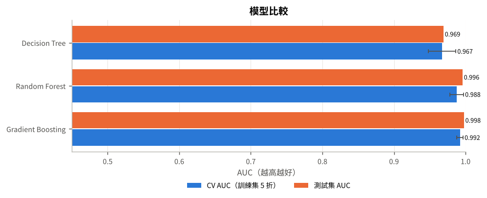

以 CV 選模型、測試集只做最終確認；誤差棒為 CV 標準差。

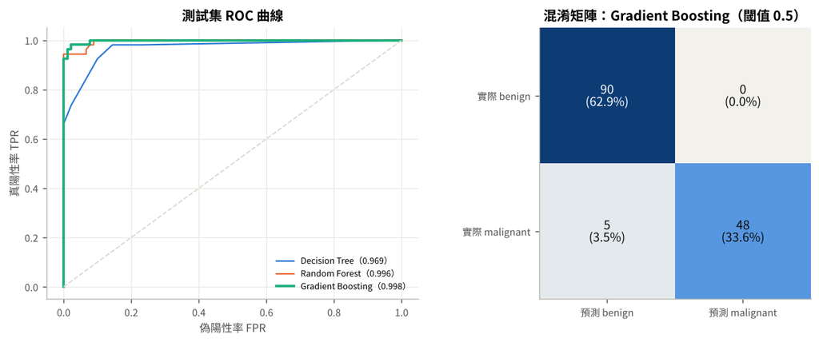

ROC 看整體排序能力；混淆矩陣在閾值 0.5 下計算，實務上應依誤判成本調整閾值。

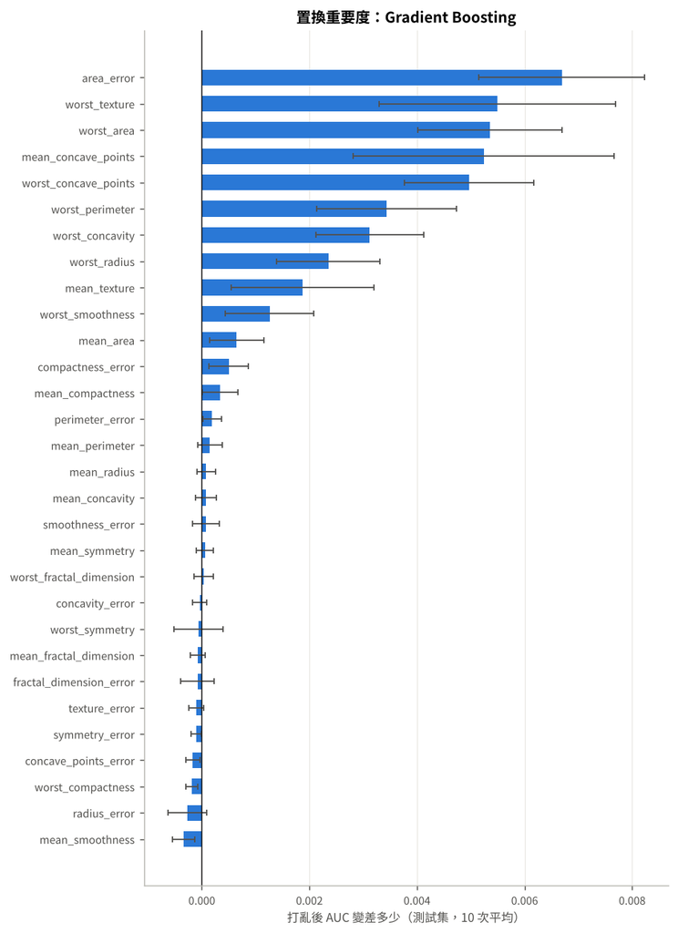

以原始欄位為單位計算（one-hot 與遺失指標一起算），比 impurity 重要度更不易被高基數 / 雜訊欄位騙。

所有表格另存於 descriptive_stats.xlsx；圖檔在 figures/。